# Derin Öğrenme Yöntemlerinden Evrişimli Sinir Ağları (CNN) ile Maske Algılama Yöntemi

COVID-19 Pandemik Hastalığının yayılması, dünyamızı ve günlük yaşamlarımızı algılama şeklimiz üzerinde derin bir etkisi olan dünyanın en önemli küresel sağlık krizini yarattı. Birçok ülke virüs pandemisinin yayılmasını kontrol etmek için yüz maskesiyle ilgili kendi kurallarını oluşturdu, ancak birçok insan, hükümet kurallarına uymayı reddetti. Polis bu insanları yakalamak için mücadele ediyor ve her birini, her yerde bulamıyorlar. Yüz algılama ve nesne algılama teknolojisi maske takmayan kişileri tespit etmeye ve polisin bu kişileri kontrol etmesine yardımcı olacak. Maske algılamanın yanı sıra, sürücünün olmadığı araba, suç tespiti, araç plaka tespiti gibi farklı gerçek zamanlı alanlarda nesne ve yüz algılama modelleri için çeşitli uygulamalar vardır. Bu çalışmada da Derin Öğrenme algoritmalarında sıkça kullanılmakta olan Evrişimsel Sinir Ağları (CNN) ile Maske Algılama Yöntemi projesini gerçekleştiriyor olacağız.

# Amaç Nedir?

Bu projedeki amacımız, veri setindeki maskeli ve maskesiz insan görsellerini doğru bir şekilde tanımlamaktır.

# Veri Seti Hakkında

Veri seti için: https://github.com/cabani/MaskedFace-Net ziyaret edebilirsiniz.

[figure not shown]

# 1) Gerekli Kütüphanelerin İmport İşlemleri ve Yüklenmesi

```python
import torch
import os
from tqdm import tqdm
import pandas as pd
import matplotlib.pyplot as plt
from pathlib import Path
import cv2
import numpy as np
import torch.nn as nn
import torch.nn.functional as F

from torch.utils.data.dataset import Dataset
from torchvision.transforms import Compose, Resize, ToPILImage, ToTensor

from torch.utils.data.dataloader import DataLoader
from torchvision.utils import make_grid
```

# 2) Veri Setinin Yüklenmesi

```python
classes = ['Non-Masked', 'Masked']

REBUILD_DATA = True

# Görüntülerin olduğu path bilgisinin tutulması
if REBUILD_DATA:
    data_path = Path('/content/drive/MyDrive/Dataset/self-built-masked-face-recognition-dataset')
    maskPath = data_path/'AFDB_masked_face_dataset'
    nonMaskPath = data_path/'AFDB_face_dataset'
    maskDF = pd.DataFrame()
    path_dirs = [ [maskPath,1],[nonMaskPath,0] ] #path and label
    if not os.path.exists(data_path):
        raise Exception("The data path doesn't exist")
```

# 2.1) Image Size ve Label Etiket Değerlerinin Belirlenmesi

```python
class MaskvNoMask():
    IMG_SIZE = 100
    LABELS = {'NON_MASKED': 0, 'MASKED': 1}
    training_data = []

    count = 0

    def make_training_data(self):
        """
    Görüntülerin dosya konumunu açar ve ilgili görüntülerin label değerlerini belirler.

    Parametreler:

    self: https://micropyramid.com/blog/understand-self-and-__init__-method-in-python-class/
        """
        for data_dir, label in path_dirs:
            print('Reading from: ',label)
            for folder in tqdm(os.listdir(data_dir)):
                folder_path = os.path.join(data_dir, folder)
                for imgpath in os.listdir(folder_path):
                    self.count += 1
                    img_path = os.path.join(folder_path, imgpath)
                    try:
                        img = cv2.imread(img_path) #imread fonksiyonu yardımı ile görüntülerin okunması
                        img = cv2.resize(img, (self.IMG_SIZE,self.IMG_SIZE)) # görüntülerin yeniden boyutlandırılması
                        self.training_data.append([np.array(img), label])
                        self.count +=1 # eklenen görüntülerin saydırılması

                        # Maskeli ve maskesiz görüntülerin sayılması ?
                        if label == 1:
                            self.LABELS['MASKED'] += 1
                        if label == 0:
                            self.LABELS['NON_MASKED'] +=1

                    except:
#                         raise Exception('error: {}'.format(img_path))
                        pass
            print(self.LABELS)
#                         raise Exception('error occured while reading , {}'.format(os.path.join(maskPath, os.path.join(subject, imgPath))))

        #veri setinde rastgelelik oluşturulması işlemi
        np.random.shuffle(self.training_data)

# Veri setinin fonksiyona verilmesi
if REBUILD_DATA:
    maskvnomask = MaskvNoMask()
    maskvnomask.make_training_data()
    training_data = maskvnomask.training_data
```

```
Reading from:  1
```

```
{'NON_MASKED': 0, 'MASKED': 2867}
Reading from:  0
```

[output not shown]

```python
# Gözütnülere ait boyut bilgisi
training_data[0][0].shape #training_data.shape, 'list' object has no attribute 'shape'
```

```
(100, 100, 3)
```

```python
# Görüntüye ait matris değerlerinin getirilmesi
training_data[0:1]
```

```
[[array([[[ 13,  18,  19],
          [ 14,  19,  20],
          [ 16,  21,  21],
          ...,
          [ 93,  95, 128],
          [ 88,  92, 125],
          [ 88,  94, 126]],

         [[ 20,  23,  24],
          [ 22,  25,  26],
          [ 22,  25,  26],
          ...,
          [ 97, 104, 133],
          [ 91, 102, 130],
          [ 91, 104, 133]],

         [[ 26,  27,  27],
          [ 30,  31,  31],
          [ 29,  31,  31],
          ...,
          [ 97, 113, 135],
          [ 92, 111, 134],
          [ 90, 112, 135]],

         ...,

         [[ 66,  80, 105],
          [ 78,  90, 118],
          [ 86,  99, 129],
          ...,
          [121, 140, 162],
          [120, 137, 160],
          [120, 137, 159]],

         [[ 60,  82, 112],
          [ 73,  88, 123],
          [ 84,  94, 131],
          ...,
          [126, 146, 167],
          [126, 145, 166],
          [125, 144, 165]],

         [[ 60,  85, 115],
          [ 72,  89, 125],
          [ 83,  93, 132],
          ...,
          [127, 147, 168],
          [128, 147, 168],
          [127, 146, 167]]], dtype=uint8), 0]]
```

# 3) Veri Setinden Örnekler Gösterilmesi

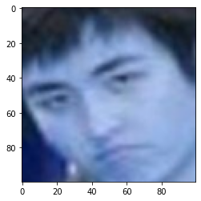

```python
#Görüntünün imshow yardımı ile görselleştirilmesi
plt.imshow(training_data[22][0])
```

```python
# Görüntüye ait label değeri
print(classes[training_data[1][1]])
```

```
Masked
```

# 4) Veri Kümesinin Oluşturulması ve Görselleştirilmesi

```python
class MaskDataset(Dataset):
        """ Masked faces dataset
        0 = 'no mask'
        1 = 'mask'
        """
        def __init__(self, train_data):
            """
        Görselleri tensor formatına çevirir.

        Parametreler:

        self: https://micropyramid.com/blog/understand-self-and-__init__-method-in-python-class/

        train_data : eğitim veri seti
            """
            self.train_data = train_data
            #https://pytorch.org/vision/stable/transforms.html
            self.transformations = Compose([
                ToTensor(),
            ])

        def __getitem__(self, key): #for understanding get item = https://www.programmersought.com/article/98542425111/
            """
        Tensor formatına çevrilen görüntülerin index bilgisini getirir.

        Parametreler:

        self: https://micropyramid.com/blog/understand-self-and-__init__-method-in-python-class/

        key: train_data'da bulunan her bir görsel

        Return:

        self.transformations(self.train_data[key][0]): Görüntü

        torch.tensor(self.train_data[key][1]: Label bilgisi
            """
            if isinstance(key, slice):
                raise NotImplementedError('slicing is not supported')
            return [
                self.transformations(self.train_data[key][0]),
                torch.tensor(self.train_data[key][1])
            ]
        # magic method : https://stackoverflow.com/questions/2481421/difference-between-len-and-len
        def __len__(self):
            return len(self.train_data)
```

```python
myDataset = MaskDataset(training_data)
```

```python
def show_example(data):
    """
    Tensor formatına çevrilen görüntülerin görselleştirilmesi.

    Parametreler:

    data : Görüntünün index bilgisi

    """
    img, label = data
    print('Label: ', classes[int(label.item())], "("+str(label.item())+")")
    plt.imshow(img.permute(1, 2, 0))
```

```python
myDataset[36]
```

```
[tensor([[[0.3255, 0.3529, 0.2980,  ..., 0.0863, 0.0980, 0.0863],
          [0.3059, 0.2784, 0.2000,  ..., 0.0863, 0.1059, 0.0980],
          [0.3608, 0.2745, 0.1725,  ..., 0.0863, 0.1059, 0.1020],
          ...,
          [0.6941, 0.6471, 0.5725,  ..., 0.0353, 0.0275, 0.0275],
          [0.3843, 0.3451, 0.2824,  ..., 0.0431, 0.0353, 0.0314],
          [0.1529, 0.1294, 0.1255,  ..., 0.0510, 0.0431, 0.0431]],

         [[0.2392, 0.2784, 0.2431,  ..., 0.0471, 0.0706, 0.0706],
          [0.2235, 0.2039, 0.1412,  ..., 0.0510, 0.0784, 0.0784],
          [0.2824, 0.1961, 0.1137,  ..., 0.0588, 0.0824, 0.0902],
          ...,
          [0.6392, 0.5961, 0.5255,  ..., 0.0392, 0.0353, 0.0431],
          [0.3373, 0.3020, 0.2392,  ..., 0.0353, 0.0314, 0.0314],
          [0.1137, 0.0902, 0.0863,  ..., 0.0314, 0.0314, 0.0314]],

         [[0.1725, 0.2157, 0.2000,  ..., 0.0235, 0.0353, 0.0275],
          [0.1490, 0.1412, 0.0980,  ..., 0.0275, 0.0431, 0.0392],
          [0.2000, 0.1373, 0.0745,  ..., 0.0392, 0.0549, 0.0510],
          ...,
          [0.5765, 0.5294, 0.4588,  ..., 0.0392, 0.0353, 0.0431],
          [0.2980, 0.2588, 0.1961,  ..., 0.0353, 0.0353, 0.0392],
          [0.0863, 0.0627, 0.0588,  ..., 0.0353, 0.0392, 0.0392]]]), tensor(0)]
```

```
Label:  Non-Masked (0)
```

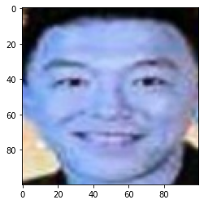

```python
show_example(myDataset[36])
```

```python
img, label = myDataset[36]
print(img.shape)
print(label)
```

```
torch.Size([3, 100, 100])
tensor(0)
```

# 4.1) Train - Validation Split İşleminin Gerçekleştirilmesi

```python
val_size = 1000
train_size = len(myDataset) - val_size

train_ds, val_ds = torch.utils.data.random_split(myDataset, [train_size, val_size])#train_test_split
len(train_ds), len(val_ds)
```

```
(3609, 1000)
```

```
Label:  Masked (1)
```

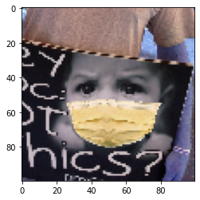

```python
show_example(val_ds[100])
```

## NOT:

https://pytorch.org/docs/stable/data.html

Linkten hareketle DataLoader'a batch size haricindeki değerleri girdikten sonra çalıştırdığımızda bu şekilde bir hata aldık:"Error rendering Jupyter widget: missing widget manager." Daha sonra bu hatayı batch_size argümanını ekleyerek çözdük.

```python
#Data loader açıklaması
#Veri setinin mini gruplara ayrılması

batch_size = 32

train_dl = DataLoader(train_ds, batch_size=batch_size*2, shuffle=True)
val_dl = DataLoader(val_ds, batch_size=batch_size*2)
```

```python
def show_batch(dl):
    """
    Veri setinden örnek görüntüleri görselleştirir.

    Parametreler:

    dl: Görüntü
    """

    for images, labels in dl:
        fig, ax = plt.subplots(figsize=(12, 6))
        ax.set_xticks([]); ax.set_yticks([])
        ax.imshow(make_grid(images, nrow=16).permute(1, 2, 0))
        break
```

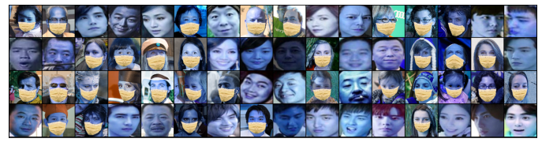

```python
show_batch(train_dl)
```

# 5) Optimizasyon ve Değerlendirme Metriklerinin Ayarlanması

```python
def accuracy(outputs, labels):
    """
    Accuracy değerini hesaplar

    Parametreler:

    outputs: Tahminlenen görüntüler
    labels: Etiket değerleri

    Return:

    torch.tensor(torch.sum(preds == labels).item() / len(preds)) : (Tahmin edilen label değerleri = görüntüye ait label değerleri) / Tüm tahminler' in toplamı
    """
    _, preds = torch.max(outputs, dim=1)
    return torch.tensor(torch.sum(preds == labels).item() / len(preds))
```

```python
class ImageClassificationBase(nn.Module):
    def training_step(self, batch):
        """
        Modele ait loss değerini hesaplar.

        Parametreler:

        self: https://micropyramid.com/blog/understand-self-and-__init__-method-in-python-class/

        batch: küçük veri grubu

        Return:

        loss: hata değerlendirme metriği
        """
        images, labels = batch
        out = self(images)                  # Generate predictions
        loss = F.cross_entropy(out, labels.long()) # Calculate loss
        return loss

    def validation_step(self, batch):
        """
        Modele ait val_loss ve val_acc değerini hesaplar.

        Parametreler:

        self: https://micropyramid.com/blog/understand-self-and-__init__-method-in-python-class/

        batch: küçük veri grubu

        Return:

        val_loss:

        val_acc :

        loss.detach() -> https://stackoverflow.com/questions/56816241/difference-between-detach-and-with-torch-nograd-in-pytorch

        """
        images, labels = batch
        out = self(images)                    # Generate predictions
        loss = F.cross_entropy(out, labels.long())   # Calculate loss
        acc = accuracy(out, labels)           # Calculate accuracy
        return {'val_loss': loss.detach(), 'val_acc': acc}

    def validation_epoch_end(self, outputs):
        """
        Küçük veri gruplarının val_loss ve val_acc değerlerinin ortalamasını hesaplar.

        Parametreler:

        self: https://micropyramid.com/blog/understand-self-and-__init__-method-in-python-class/

        outputs: Tahminlenen görüntüler

        Return:

        val_loss:

        val_acc :

        item() -> https://www.programiz.com/python-programming/methods/dictionary/items
        """
        batch_losses = [x['val_loss'] for x in outputs]
        epoch_loss = torch.stack(batch_losses).mean()   # Combine losses
        batch_accs = [x['val_acc'] for x in outputs]
        epoch_acc = torch.stack(batch_accs).mean()      # Combine accuracies
        return {'val_loss': epoch_loss.item(), 'val_acc': epoch_acc.item()}

    def epoch_end(self, epoch, result):
        """
        Hesaplanan train_loss,val_loss ve val_acc değerlerini bastırır.

        Parametreler:

        self: https://micropyramid.com/blog/understand-self-and-__init__-method-in-python-class/

        epoch: Epoch sayısı, model eğitilirken verilerin modelden kaç kez geçiş yapacağını belirtir.

        result: Sonuç
        """
        print("Epoch [{}], train_loss: {:.4f}, val_loss: {:.4f}, val_acc: {:.4f}".format(
            epoch, result['train_loss'], result['val_loss'], result['val_acc']))
    def predict():
        """
        Tahmin değerlerinden iki sınıf arasında max olan değeri alır.
        """
        pred = model(img)
        _, preds = torch.max(pred, dim=1)
```

# 6) Modelleme

- **Sequential:** Sequential model Pytorch'un bize sunmuş olduğu sinir ağı kurma yöntemidir. Sequential kelime anlamı olarak sıralı anlamına gelmektedir ve bu yapı sayesinde sıralı katmanlardan oluşan bir sinir ağı kolayca oluşturabilir.
- **Evrişim Katmanı (Convolution Layer, Conv2D):** Bu katmanda giriş görüntüsü üzerinden öznitelik (kenar bulma, köşe bulma, görüntü üzerinde nesne bulma) çıkarımı yapılmaktadır. Bu çıkarım filtreler aracılığı ile gerçekleştirilmektedir.
  - **Conv2D:**
    - **in_channels :** Giriş görüntüsündeki kanal sayısı
    - **out_channels:** Evrişim tarafından üretilen kanal sayısı
    - **kernel_size :** Gezdirilecek olan filtrenin boyut bilgisi
    - **padding:** Girdinin soluna/sağına veya yukarı/aşağı eşit olarak sıfırlarla doldurma işlemi
- **Aktivasyon Fonksiyonu Katmanı (Activation Layer):** Yapay sinir ağlarına doğrusal olmayan gerçek dünya özelliklerini tanıtmak için aktivasyon fonksiyonlarına ihtiyaç duyulmaktadır. Relu, tanh, sigmoid gibi aktivasyon fonksiyonları yaygın olarak kullanılmaktadır. Son katmanda ilgili probleme göre aktivasyon fonksiyonu değişkenlik gösterebilir. Eğer çoklu bir sınıflandırma problemi söz konusu ise bu durumda çıkış katmanındaki aktivasyon fonksiyonu olarak softmax kullanılabilir. Tek sınıflı bir sınıflandırma problemi söz konusu ise bu durumda çıkış katmanındaki aktivasyon fonksiyonu olarak sigmoid kullanılabilir.
  - **ReLU:** Doğrultulmuş lineer birim (rectified linear unit- RELU) doğrusal olmayan bir fonksiyondur. ReLU fonksiyonu negatif girdiler için 0 değerini alırken, x pozitif girdiler için x değerini almaktadır.
- **Piksel Ekleme (Padding):** Evrişim işlemi sonrasında giriş matrisi boyutu ile çıkış matrisi boyutu birbirine eşit olmadığından dolayı bu problemin önüne geçebilmek için piksel ekleme (padding) işlemi gerçekleştirilerek giriş matrisi boyutu ile çıkış matrisi boyutu arasındaki oluşan boyut farkı ortadan kaldırılmaktadır.
- **Havuzlama Katmanı (Pooling Layer):** En temelde görüntünün özelliklerini kaybetmeden boyutunun azaltılması işlemi gerçekleştirilmektedir. Karşınıza down sampling (boyut azaltma) olarak da çıkabilmektedir. Bu katmanda herhangi bir öğrenme işlemi yapılmamaktadır. Evrişim katmanı sonrasında kullanılan bir katmandır.
  - **Maksimum Havuzlama (Maximum Pooling):** Evrişim işleminden sonra oluşan çıktı matrisi üzerinde filtrenin gezmiş olduğu noktaların maksimum değeri alınarak çıkış matrisi oluşturulmaktadır.
    - **MaxPool2d:**
      - **kernel_size :** Gezdirilecek olan filtrenin boyut bilgisi
      - **stride :** Stride değeri CNN modellerinde parametre olarak değiştirilebilen bir değerdir. Bu değer filtrenin ana görsel üzerinde kaç piksel boyunca kayacağını belirler.
      - **dilation:** Çekirdek noktaları arasındaki boşluğu kontrol eder
- **Flattening Katmanı:** Yapay sinir ağları, giriş verilerini tek boyutlu bir diziden alır. Flattening katmanı Convolutional ve Pooling katmanından gelen matrislerin tek boyutlu diziye çevrilmesi işlemini gerçekleştirmektedir.
- **Linear Katmanı:** Bu katmanda gelen verilere doğrusal bir dönüşüm uygulanır.
  - **in_features=80000:** Her girdi örneğinin boyutu
  - **out_features=1024:** Her çıktı örneğinin boyutu

```python
class MaskDetection(ImageClassificationBase):
    def __init__(self):
        super().__init__()
        self.network = nn.Sequential(
            nn.Conv2d(3, 100, kernel_size=3, padding=1),
            nn.ReLU(),
            nn.Conv2d(100, 128, kernel_size=3, stride=1, padding=1),
            nn.ReLU(),
            nn.MaxPool2d(2, 2), # output: 128 x 8 x 8

            nn.Conv2d(128, 256, kernel_size=3, stride=1, padding=1),
            nn.ReLU(),
            nn.Conv2d(256, 256, kernel_size=3, stride=1, padding=1),
            nn.ReLU(),
            nn.MaxPool2d(2, 2), # output: 256 x 4 x 4

            nn.Flatten(),
            nn.Linear(160000, 512),
            nn.ReLU(),
            nn.Linear(512, 256),
            nn.ReLU(),
            nn.Linear(256, 2))

    def forward(self, xb):
        """
        forward method : https://discuss.pytorch.org/t/forward-method-call-for-weight-training/84314
        """
        return self.network(xb) # xb = weights and biases
```

```python
class MaskDetection1(ImageClassificationBase):
    def __init__(self):
        super().__init__()
        self.network = nn.Sequential(
            nn.Conv2d(3, 32, kernel_size=3, padding=1),
            nn.ReLU(),
            nn.Conv2d(32, 64, kernel_size=3, stride=1, padding=1),
            nn.ReLU(),
            nn.MaxPool2d(2, 2), # output: 64 x 8 x 8

            nn.Conv2d(64, 128, kernel_size=3, stride=1, padding=1),
            nn.ReLU(),
            nn.MaxPool2d(2, 2), # output: 128 x 4 x 4

            nn.Flatten(),
            nn.Linear(80000, 1024),
            nn.ReLU(),
            nn.Linear(1024, 2))



    def forward(self, xb):
        return self.network(xb) # xb = weights and biases
```

# 6.2) Ekran Kartı Ayarlarının Yapılması

```python
# Eğitim esnasında ekran kartının aktif olup olmadığının kontrol edilmesi
torch.cuda.is_available()
```

```
True
```

```python
def get_default_device():
    """
    Ekran kartı kontrollerini gerçekleştirir.
    """
    if torch.cuda.is_available():
        return torch.device('cuda')
    else:
        return torch.device('cpu')
```

```python
# Ekran kartı bilgisi
device = get_default_device()
device
```

```
device(type='cuda')
```

```python
def to_device(data, device):
    """
    Görüntüye ait tensor değerlerini ekran kartına aktarır.

    Parametreler:

    data: Tensor formatına çevrilmiş görüntüler

    device: Ekran kartı

    Return:

    device: Ekran kartı
    non_blocking -> https://jovian.ai/forum/t/purpose-of-non-blocking-true-in-tensor-to/14760
    """
    #move tensors to device
    if isinstance(data, (list,tuple)):
        return [to_device(x, device) for x in data]
    return data.to(device, non_blocking=True)
```

```python
# Görüntünün boyut bilgisini bastırır.

for images, labels in train_dl:
    print(images.shape)
    images = to_device(images, device)
    print(images.device)
    break
```

```
torch.Size([64, 3, 100, 100])
cuda:0
```

# 6.3) Veri Setinin Ekran Kartına Aktarılması

```python
class DeviceDataLoader():
    #move data to a device
    def __init__(self, dl, device):
        self.dl = dl
        self.device = device

    def __iter__(self):
        #Yield a batch of data after moving it to device
        for b in self.dl:
            yield to_device(b, self.device)

    def __len__(self):
        #Number of batchs
        return len(self.dl)
```

```python
# Train ve Validation setlerinin aktarılması
train_dl = DeviceDataLoader(train_dl, device)
val_dl = DeviceDataLoader(val_dl, device)
```

```python
# xb = Ekran kartının çalışma bilgisi
# yb = mini veri grubuna (batch_size) ait görüntülerin label değerleri
for xb, yb in val_dl:
    print('xb.device:', xb.device)
    print('yb:', yb)
    break
```

```
xb.device: cuda:0
yb: tensor([0, 1, 1, 1, 0, 0, 0, 0, 1, 1, 0, 0, 1, 1, 1, 1, 0, 1, 1, 0, 1, 0, 0, 0,
        1, 0, 0, 1, 1, 0, 1, 1, 1, 1, 0, 1, 1, 1, 0, 0, 0, 1, 1, 0, 1, 1, 1, 1,
        1, 1, 0, 1, 1, 0, 1, 0, 1, 1, 0, 1, 1, 1, 1, 1], device='cuda:0')
```

```python
@torch.no_grad()
def evaluate(model, val_loader):
    """
    https://discuss.pytorch.org/t/model-train-and-model-eval-vs-model-and-model-eval/5744
    """
    model.eval()
    outputs = [model.validation_step(batch) for batch in val_loader]
    return model.validation_epoch_end(outputs)

def fit(epochs, lr, model, train_loader, val_loader, opt_func=torch.optim.SGD):
    """

    Modeli eğitir


    Parametreler :

    epochs: Epoch sayısı, model eğitilirken verilerin modelden kaç kez geçiş yapacağını belirtir.

    lr: Öğrenme oranı

    model.parameters: Moel parametreleri

    train_loader: Eğitim veri seti

    val_loader: Validasyon veri seti

    opt_func: Optimizasyon Fonksiyonu


    Return:

    history: Modele ağit eğitim verileri
    """
    history = []
    optimizer = torch.optim.SGD(model.parameters(), lr=0.001, momentum=0.9)
    for epoch in range(epochs):
        print('epoch: ', epoch)
        model.train()
        train_losses = []
        for batch in train_loader:
            loss = model.training_step(batch)
            train_losses.append(loss)
            loss.backward()
            optimizer.step()
            optimizer.zero_grad()
        result = evaluate(model, val_loader)
        result['train_loss'] = torch.stack(train_losses).mean().item()
        model.epoch_end(epoch, result)
        history.append(result)
    return history
```

```python
# Model (on GPU)
model = MaskDetection1()
to_device(model, device)
```

```
MaskDetection1(
  (network): Sequential(
    (0): Conv2d(3, 32, kernel_size=(3, 3), stride=(1, 1), padding=(1, 1))
    (1): ReLU()
    (2): Conv2d(32, 64, kernel_size=(3, 3), stride=(1, 1), padding=(1, 1))
    (3): ReLU()
    (4): MaxPool2d(kernel_size=2, stride=2, padding=0, dilation=1, ceil_mode=False)
    (5): Conv2d(64, 128, kernel_size=(3, 3), stride=(1, 1), padding=(1, 1))
    (6): ReLU()
    (7): MaxPool2d(kernel_size=2, stride=2, padding=0, dilation=1, ceil_mode=False)
    (8): Flatten(start_dim=1, end_dim=-1)
    (9): Linear(in_features=80000, out_features=1024, bias=True)
    (10): ReLU()
    (11): Linear(in_features=1024, out_features=2, bias=True)
  )
)
```

```python
# Model ağırlıklarının kaydedilmesi
checkpoint_path = os.path.join(os.getcwd(), "checkpoints")
torch.save(model.state_dict(), checkpoint_path)
```

```python
history = [evaluate(model, val_dl)]
history
```

```
[{'val_acc': 0.3833984434604645, 'val_loss': 0.70118647813797}]
```

```python
epoch=4
history = fit(epoch, 1e-3, model, train_dl, val_dl)
```

```
epoch:  0
Epoch [0], train_loss: 0.6368, val_loss: 0.5893, val_acc: 0.6166
epoch:  1
Epoch [1], train_loss: 0.4444, val_loss: 0.1969, val_acc: 0.9926
epoch:  2
Epoch [2], train_loss: 0.0615, val_loss: 0.0171, val_acc: 0.9980
epoch:  3
Epoch [3], train_loss: 0.0110, val_loss: 0.0090, val_acc: 0.9980
```

# 6.4) Sonuçların Görselleştirilmesi

```python
def plot_losses(history):
    """
    Modele ait Validation Loss grafiğini çizdirir.

    Parametreler:

    history: Modele ağit eğitim verileri
    """
    losses = [x['val_loss'] for x in history]
    plt.plot(losses, '-x')
    plt.xlabel('epoch')
    plt.ylabel('loss')
    plt.title('Validation Loss');
```

```python
def plot_accuracies(history):
    """
    Modele ait Validation Accuracy grafiğini çizdirir.

    Parametreler:

    history: Modele ağit eğitim verileri
    """
    accuracies = [x['val_acc'] for x in history]
    plt.plot(accuracies, '-x')
    plt.xlabel('epoch')
    plt.ylabel('accuracy')
    plt.title('Validation Accuracy');
```

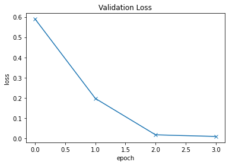

```python
plot_losses(history)
```

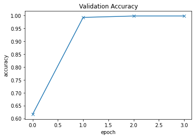

```python
plot_accuracies(history)
```

# 7) Model Başarı Değerlendirme

# 7.1) Confusion Matrix

[figure not shown]

```python
nb_classes = 2

confusion_matrix = torch.zeros(nb_classes, nb_classes)
with torch.no_grad():
    for i, (inputs, classes) in enumerate(val_dl):
        inputs = inputs.to(device)
        classes = classes.to(device)
        outputs = model(inputs)
        _, preds = torch.max(outputs, 1)
        for t, p in zip(classes.view(-1), preds.view(-1)):
                confusion_matrix[t.long(), p.long()] += 1

print(confusion_matrix)
```

```
tensor([[382.,   1.],
        [  1., 616.]])
```

# 8) Modelin Test Edilmesi

```python
import matplotlib.image as mpimg
def singleImage(path, label= None, show= False):
    img = cv2.imread(path)
    assert img is not None,"Immage wasn't read properly"
    img = cv2.resize(img, (100, 100))
    img = torch.from_numpy(img)
    img = img.permute((2, 0,1)) # model expects image to be of shape [3, 100, 100]
    img = img.unsqueeze(dim=0).float() # convert single image to batch [1, 3, 100, 100]
    img = img.to('cuda') # Using the same device as the model
    pred = model(img)
    _, preds = torch.max(pred, dim=1)
    print(classes[preds.item()])
    #plt.imshow(img.squeeze(dim=0).permute((1,2,0)).to('cpu'))

    if show:
        plt.imshow(mpimg.imread(path))
        print("the image is :" + classes[preds.item()])
```

[output not shown]

[output not shown]

[output not shown]

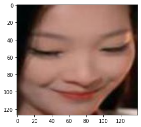

```python
singleImage('/content/drive/MyDrive/Dataset/self-built-masked-face-recognition-dataset/AFDB_face_dataset/hedujuan/1_0_hedujuan_0134.jpg', show=True)
```